# Random Forest Prediction Model for the Evaluation of Performance of Unilateral Dumbbell Biceps Curls

Joel Chavez Gomez

January 26, 2022

## Introduction

One thing that people regularly do is quantify how much of a particular activity they do, but they rarely quantify how well they do it. In this project, the goal is to use data from accelerometers on the belt, forearm, arm, and dumbell of 6 participants from the [Human Activity Recognition](http://web.archive.org/web/20161224072740/http:/groupware.les.inf.puc-rio.br/har#weight_lifting_exercises) Study.

On this study, participants were asked to perform one set of 10 repetitions of the Unilateral Dumbbell Biceps Curl in five different fashions:  
- Exactly according to the specification (Class A)  
- Throwing the elbows to the front (Class B)  
- Lifting the dumbbell only halfway (Class C)  
- Lowering the dumbbell only halfway (Class D)  
- Throwing the hips to the front (Class E)

Class A corresponds to the specified execution of the exercise, while the other 4 classes correspond to common mistakes. Participants were supervised by an experienced weight lifter to make sure the execution complied to the manner they were supposed to simulate. The exercises were performed by six male participants aged between 20-28 years, with little weight lifting experience.

### Data

The training data for this project are available [here](https://d396qusza40orc.cloudfront.net/predmachlearn/pml-training.csv)

The test data are available [here](https://d396qusza40orc.cloudfront.net/predmachlearn/pml-testing.csv) The data for this project come from this [source](http://groupware.les.inf.puc-rio.br/har)

### Objective

The goal of this project is to predict the manner in which the subjects did the exercise. This is the “classe” variable in the training set. You may use any of the other variables to predict with. You should create a report describing how you built your model, how you used cross validation, what you think the expected out of sample error is, and why you made the choices you did. You will also use your prediction model to predict 20 different test cases.

## Data Analysis

Libraries are loaded, the data sets files are downloaded and read into two data frames, `training` for the training data set, and `testing` for the testing data set.

```r
library(tidyverse); library(caret)
```

```r
Train.url <- "https://d396qusza40orc.cloudfront.net/predmachlearn/pml-training.csv"
Test.url <- "https://d396qusza40orc.cloudfront.net/predmachlearn/pml-testing.csv"
if(!file.exists("DataSets/pml-training.csv")){
download.file(Train.url, destfile = "DataSets/pml-training.csv")
}
if(!file.exists("DataSets/pml-testing.csv")){
download.file(Test.url, "DataSets/pml-testing.csv")
}
training <- read.csv("./DataSets/pml-training.csv", header = TRUE)
testing <- read.csv("./DataSets/pml-testing.csv", header = TRUE)
```

## Data Preparation

The data sets consists of measurements from accelerometers on the belt, forearm, arm, and dumbbell of 6 participants, as explained on the introduction. The training data set consists of 19622 observations from 160 variables. The first 7 columns from our data frame consists of ID variables, so they were removed. Then all other variables,except the classification variable, were converted into numeric values.

```r
dim(training)
```

```
## [1] 19622   160
```

```r
train_data <- training[-c(1:7)]
train_data <- sapply(train_data[, -c(153)], as.numeric)
train_data <- as.data.frame(train_data)
```

```r
# Removing features with near zero variance
train_nzv <- nearZeroVar(train_data)
train_data <- train_data[, -train_nzv]

# Removing highly correlated features
M <- abs(cor(train_data))
M[!lower.tri(M)] <- 0
high_cor_features <- which(M > 0.8, arr.ind = TRUE)
train_data <- train_data[, !apply(M, 2,
                                  function(x) any(abs(x) > 0.8, na.rm = TRUE))]

# Removing features with NA values
train_data <- train_data[lapply(train_data,
                                function(x) sum(is.na(x))/length(x) ) < 0.9 ]

# Adding classification var
train_data$classe <- training$classe
train_data$classe <- as.factor(train_data$classe)
```

```r
set.seed(125)
inTrain <- createDataPartition(y = train_data$classe, p = 0.8, list = FALSE)
train_data <- train_data[inTrain, ]
val_data <- train_data[-inTrain, ]
```

3-fold cross validation will be used for model fitting.

```r
fitControl <- trainControl(method = "cv", number = 3)
```

## Model Creation

A **Gradient Boosting Machine** model and a **Random Forest** model were created.

```r
gbmFit1 <- train(classe ~ ., data = train_data,
                 method = "gbm",
                 trControl = fitControl,
                 verbose = FALSE)
rfFit <- train(classe ~ ., data = train_data,
               trControl = fitControl,
               method = "rf")
```

Below are the plots of bot models

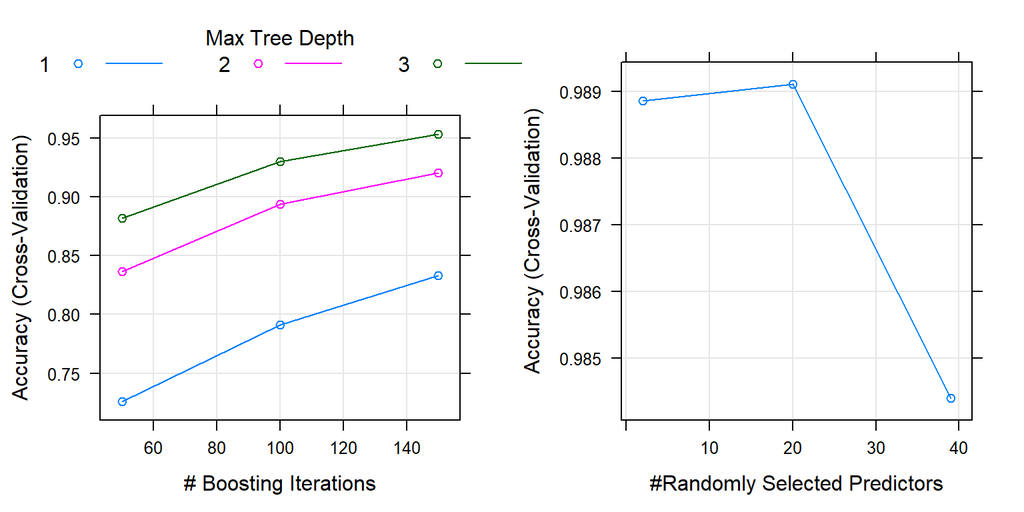

```r
library(gridExtra)
grid.arrange(plot(gbmFit1), plot(rfFit), nrow = 1)
```

```r
gbm_pred <- predict(gbmFit1, val_data)
rf_pred <- predict(rfFit, val_data)
gbm_cm <- confusionMatrix(gbm_pred, val_data$classe)
gbm_cm
```

```
## Confusion Matrix and Statistics
##
##           Reference
## Prediction   A   B   C   D   E
##          A 879  17   0   1   0
##          B   5 600  11   3   2
##          C   1   9 508  17   4
##          D   0   0   8 497   4
##          E   0   1   2   3 556
##
## Overall Statistics
##
##                Accuracy : 0.9719
##                  95% CI : (0.9655, 0.9774)
##     No Information Rate : 0.2829
##     P-Value [Acc > NIR] : < 2.2e-16
##
##                   Kappa : 0.9644
##
##  Mcnemar's Test P-Value : NA
##
## Statistics by Class:
##
##                      Class: A Class: B Class: C Class: D Class: E
## Sensitivity            0.9932   0.9569   0.9603   0.9539   0.9823
## Specificity            0.9920   0.9916   0.9881   0.9954   0.9977
## Pos Pred Value         0.9799   0.9662   0.9425   0.9764   0.9893
## Neg Pred Value         0.9973   0.9892   0.9919   0.9908   0.9961
## Prevalence             0.2829   0.2004   0.1691   0.1666   0.1809
## Detection Rate         0.2810   0.1918   0.1624   0.1589   0.1777
## Detection Prevalence   0.2868   0.1985   0.1723   0.1627   0.1797
## Balanced Accuracy      0.9926   0.9743   0.9742   0.9747   0.9900
```

```r
rf_cm <- confusionMatrix(rf_pred, val_data$classe)
rf_cm
```

```
## Confusion Matrix and Statistics
##
##           Reference
## Prediction   A   B   C   D   E
##          A 885   0   0   0   0
##          B   0 627   0   0   0
##          C   0   0 529   0   0
##          D   0   0   0 521   0
##          E   0   0   0   0 566
##
## Overall Statistics
##
##                Accuracy : 1
##                  95% CI : (0.9988, 1)
##     No Information Rate : 0.2829
##     P-Value [Acc > NIR] : < 2.2e-16
##
##                   Kappa : 1
##
##  Mcnemar's Test P-Value : NA
##
## Statistics by Class:
##
##                      Class: A Class: B Class: C Class: D Class: E
## Sensitivity            1.0000   1.0000   1.0000   1.0000   1.0000
## Specificity            1.0000   1.0000   1.0000   1.0000   1.0000
## Pos Pred Value         1.0000   1.0000   1.0000   1.0000   1.0000
## Neg Pred Value         1.0000   1.0000   1.0000   1.0000   1.0000
## Prevalence             0.2829   0.2004   0.1691   0.1666   0.1809
## Detection Rate         0.2829   0.2004   0.1691   0.1666   0.1809
## Detection Prevalence   0.2829   0.2004   0.1691   0.1666   0.1809
## Balanced Accuracy      1.0000   1.0000   1.0000   1.0000   1.0000
```

## Model Testing

```
##   Model Accuracy OoSError
## 1   GBM   0.9719   0.0281
## 2    RF   1.0000   0.0000
```

```r
rf_test <- predict(rfFit, testing)
rf_test
```

```
##  [1] B A B A A E D B A A B C B A E E A B B B
## Levels: A B C D E
```

## Conclusion

The Random Forest Model was better to predict the outcome in the validation data set.